# Reproducible Research: Peer Assessment 1

## Loading and preprocessing the data

Set the working directory and load packages needed

```r
setwd("C:/_almacen/coursera/reproducible research/course project 1")
library(dplyr)
library(ggplot2)
library(lattice)
library(knitr)
```

##### 1. Load the data:

```r
raw_data<- read.csv("activity.csv", na.strings= "NA", header= TRUE)
```

##### 2. Transform “date” variable to Date format:

```r
raw_data$date= as.Date(as.character(raw_data$date), "%Y-%m-%d")
```

## What is mean total number of steps taken per day?

##### 1. Calculate the total number of steps taken per day (dplyr library was used)

```r
steps_per_day<- raw_data %>%
        group_by(date) %>%
        summarize(total= sum(steps, na.rm= TRUE))
```

##### 2. Make a histogram of the total number of steps taken each day (ggplot2 library was used)

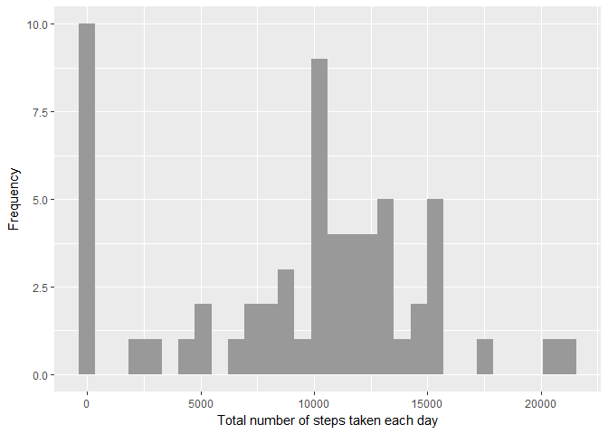

```r
p1<- ggplot(steps_per_day, aes(total))+ geom_histogram(fill= "grey60")
p1<- p1+ xlab("Total number of steps taken each day")+ ylab("Frequency")
print(p1)
```

##### 3. Calculate and report the mean and median of the total number of steps taken per day

```r
print(paste("The mean of the total number of steps taken each day is: ", round(mean(steps_per_day$total), 2)))
```

```
## [1] "The mean of the total number of steps taken each day is:  9354.23"
```

```r
print(paste("The median of the total number of steps taken each day is: ", median(steps_per_day$total)))
```

```
## [1] "The median of the total number of steps taken each day is:  10395"
```

## What is the average daily activity pattern?

##### 1. Make a time series plot of the 5-minute interval (x-axis) and the average number of steps taken, averaged across all days (y-axis) (ggplot2 library was used)

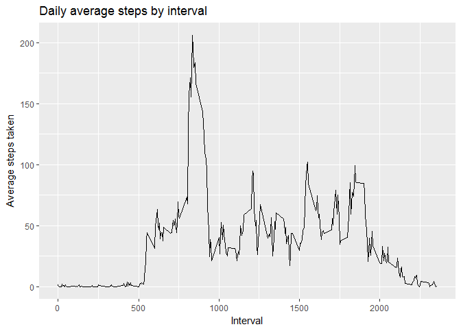

```r
# Calculate the average number of steps taken by interval
interval_average<- raw_data %>%
        group_by(interval) %>%
        summarize(ave= mean(steps, na.rm= TRUE))

p2<- ggplot(interval_average, aes(interval, ave)) + geom_line()
p2<- p2+ ggtitle("Daily average steps by interval")+ xlab("Interval")+ ylab("Average steps taken")
print(p2)
```

##### 2. Which 5-minute interval, on average across all the days in the dataset, contains the maximum number of steps?

```r
max_interval<- which.max(interval_average$ave)
print(paste("The 5-minute interval that contains the maximum number of steps is ", interval_average[max_interval, 1]))
```

```
## [1] "The 5-minute interval that contains the maximum number of steps is  835"
```

## Imputing missing values

##### 1. Calculate and report the total number of missing values in the dataset

```r
print(paste("There are", sum(is.na(raw_data)), "missing values in the dataset"))
```

```
## [1] "There are 2304 missing values in the dataset"
```

##### 2. Devise a strategy for filling in all of the missing values in the dataset.

To impute the data, the 5-minute interval mean for all days will be used.

##### 3. Create a new dataset that is equal to the original dataset but with the missing data filled in (dplyr library was used).

```r
imputed_data<- raw_data %>%
        left_join(interval_average) %>%
        mutate(steps= ifelse(is.na(steps), ave, steps))
```

[figure not shown]

```r
p3<- ggplot(imputed_data, aes(steps))+ geom_histogram(fill= "grey60")
p3<- p3+ xlab("Total number of steps taken each day with imputed data")+ ylab("Frequency")
print(p3)
```

```r
print(paste('The mean of the total number of steps taken each day is:', round(mean(imputed_data$steps), 2)))
```

[output not shown]

```r
print(paste('The median of the total number of steps taken each day is:', median(imputed_data$steps)))
```

[output not shown]

## Are there differences in activity patterns between weekdays and weekends?

```r
imputed_data<- imputed_data %>%
        mutate(date= as.Date(as.character(date, "%Y-%m-%d"))) %>%
        mutate(weekday= weekdays(date)) %>%
        mutate(week_factor= ifelse(weekday== "sabado"| weekday== "domingo", "weekend", "weekday")) %>%
        group_by(interval, week_factor) %>%
        summarize(ave_f= mean(steps))
```

##### 2. Make a panel plot containing a time series plot of the 5-minute interval (x-axis) and the average number of steps taken, averaged across all weekday days or weekend days (y-axis) (lattice library was used)

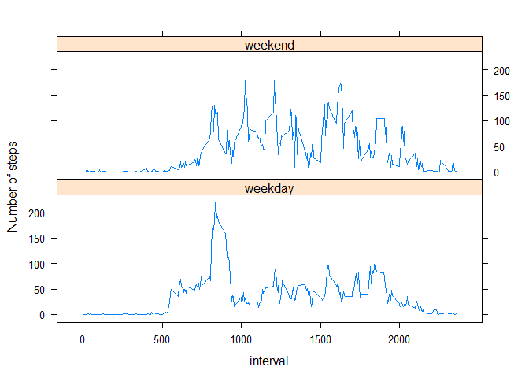

```r
xyplot(ave_f~ interval| week_factor, data=imputed_data, layout= c(1, 2), type= "l", ylab= "Number of steps")
```